# Breve revisión de scikit-learn

La biblioteca principal que se usará en el material será scikit-learn, ésta concentra la mayoría de algoritmos de Aprendizaje Automático más usados. Además cuenta con otro tipo de algoritmos, qué van desde selección de variables, optimización de parámetros, validación cruzada y pipelines para unir todos los procesos.

[figure not shown]

## Consideraciones

Los algoritmos que se incluyen en dicha biblioteca son solo aquellos que están bien establecidos, muy conocidos y ampliamente usados. Entre las reglas que se consideran para incluir algún algoritmo es que cuenta con *al menos 3 años desde su publicación*, más de *200 citas* y que sea *ampliamente usado*. Esto va desde algoritmos de selección de variables, algoritmos de optimización para mejorar las estimaciones, etc.

No se incluye entre los algoritmos ninguno que tenga que ver con [Deep Learning](http://www.deeplearningbook.org/) (Aprendizaje Profundo) o [Reinforcement Learning](http://people.inf.elte.hu/lorincz/Files/RL_2006/SuttonBook.pdf) ( Aprendizaje por Reforzamiento). Otro tema que no está fuera de esta biblioteca son [Modelos Oculto de Márkov](http://cs229.stanford.edu/section/cs229-hmm.pdf) ( HMM).

Las razones son diversas,que van desde el objetivo a cubrir con esta biblioteca hasta su "arquitectura".

## ¿Qué algoritmos están disponibles?

Lista de Algirtmos:

- Modelos Lineales Generalizados
- Análisis Discriminante Lineal
- Maquina de Soporte Vectorial
- Gradiente Descendente Estocástico
- Vecinos Cercanos
- Procesos Gaussianos
- Árboles de Decisión
- Modelos Ensamble
- Modelos de Mezclas Gausianas
- Variadades de Aprendizaje
- Cluster
- Factorización de Matrices

Cada uno de los anteriores forman una familia de algoritmos, en algunos casos son algoritmos para clasificación y regresión. También contiene algoritmos que son útiles para transformación y selección de variables; también cuenta con algoritmos para busqueda de parámetros y pruebas de validación cruzada.

Liga para ver la lista de algoritmos que se encuentran:

- [Guía de Uso](http://scikit-learn.org/stable/user_guide.html)

## Documentación

La biblioteca tiene suficiente documentación sobre cada uno de los algoritmos que incluye, casi todas las funciones cuentan con ejemplos. Si bien, no es una documentación extensa en cada tema, se cuenta con referencias, tanto libros de texto como artículos de investigación.

Para aprender a manejar las funciones disponibles se puede iniciar en tutorial de la documentación:

[figure not shown]

## Ejemplo Sencillo

Se hace una regresión lineal como ejemplo.

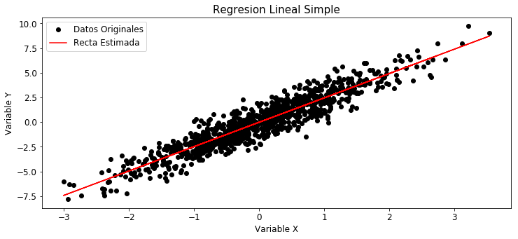

```python
#Codigo de la regresión lineal


%matplotlib inline
import matplotlib.pyplot as plt
import numpy as np
from sklearn.linear_model import LinearRegression


#configuraciones de tipo de gráficos y de tamaño
plt.rcParams["figure.figsize"] = (12, 5)
plt.rcParams['figure.titlesize'] = 'large'
plt.rcParams['font.size'] = 12
plt.rcParams['axes.titlesize']=15

#Se generan los datos
x=np.random.normal(size=1000)
y=np.random.normal(size=1000)+2.5*x

#Se define el modelo
Modelo=LinearRegression()
Modelo.fit(x.reshape((-1,1)),y)

#Se realiza una predicción
Pred=Modelo.predict(x.reshape((-1,1)))

#Se grafican los datos
plt.plot(x,y,'ko')
plt.plot(x,Pred,'r-')
plt.legend(['Datos Originales','Recta Estimada'])
plt.title("Regresion Lineal Simple")
plt.xlabel("Variable X")
plt.ylabel("Variable Y")
```

Para el ejemplo anterior se generan datos aleatorios que son definidos como variables $x$ y $y$, intencionalmente los datos son generados desde una *distribución normal*. La relación entre las variables es: $$y=2.5x+\epsilon$$

Donde $\epsilon \in N(0,1)$, donde con $N$ se indica que es una distribución normal con media cero y varianza $1$. Solo se realizó la estimación de la recta mediante el modelo `LinearRegression()`. Más adelante se explican detalles al respecto de los modelos lineales.

## R vs Python

Mi opinión desde un punto de vista práctico no hay ningúna competencia entre R y Python. Al contrario, conocer algo de los dos lenguajes ayuda ante algún proyecto de Aprendizaje Automático. Pero resulta más fundamental conocer las bases de los algoritmos, ya que se puede caer en el mal hábito de hacer uso de los compandos o bibliotecas pero no profundizar en qué es lo que ocurre detras a bajo nivel.

Para el reto de implementar algún algoritmos de manera distribuida, pese a que R y Python cuentan con cierta capacidad para abordar ese reto, no resultan ser "óptimos". Ante ese tipo de reto, hay otras alternativas qué se han estado madurando en años recientes.

- [Spark](https://spark.apache.org/)
- [Julia/ aún en desarrollo](https://julialang.org/)

## Similitudes con scikit-learn

En R, se cuenta con diversar bibliotecas que tienen algoritmos de Aprendizaje Automático, quizás el entorno que se ha desarrollado para contar con todo el proceso que van desde *pre-procesamiento, selección de variables, transformación de variables, entrenamiento y predicción* es [**Caret**](http://topepo.github.io/caret/index.html) quizás sea el entorno más similar a lo disponible en scikit-learn.

## Diferencias

En R se puden encontrar muchas bibliotecas que tiene algúnos algoritmos que no están en scikit-learn, o se pueden encontrar varias biblitecas que hacen uso de un mismo algoritmo pero presentan alguna versión distinta del método de estimación de parámetros.

Una razón es que en scikit-learn se controla el tipo de algoritmos que se van incluyendo bajo el criterio de que sean algoritmos bien establecidos, conocidos, estudiados y sobre todo considerablemente muy usados. Mientras en R se pueden encontar muchas biblitecas de algoritmos experimentales o de reciente creación.

## Ejercicios

Los siguientes ejercicios son solo ejecuciones de código con la intención de conocer como funcionan los modelos o algoritmos en scikit-learn. Cada ejercicio está relacionado con el código previo.

```python
# 1.- Ejecuta el siguiente código para cargar los modelos lineales para regresión y clasificación

from sklearn.linear_model import LinearRegression, LogisticRegression
```

```python
# 2.- Exploración de métodos: cada modelo es un "objeto" que cuenta con ciertos métodos
#     comparar los métodos que se tienen en un modelo para regresión y uno de clasificación
#Ejemplo: Si ejecuta 'LinearRegression.<Tab>' en una celda, se muestran los métodos de ese modelo
#         por ejemplo se pueden mostrar LinearRegression.fit

#Para ver todos los métodos como una lista se puede ejecutar el siguiete, donde object=LinearRegression o LogisticRegression

[metodos for metodos in dir(object) if callable(getattr(object, metodos)) if not str(metodos).count("_")>2]
```

```python
# 3.- Comparar los Métodos asociados al modelo Logístico y a la Regresión Lineal. Revisar la información
#     para '.fit', '.score' y para 'get_params'
# Se puede relizar con líneas de código similares a
?LinearRegression.fit
```

```python
# 4.- Import un método kmeans de las técnicas de clusterign y ver su métodos,¿Se tienen los mismos             métodos?

from sklearn.cluster import KMeans
[metodos for metodos in dir(KMeans) if callable(getattr(KMeans, metodos)) if not str(metodos).count("_")>2]
```